# team

```r
choco = read.csv("https://xdaiisu.github.io/ds202materials/hwlabs/choco.csv")
head(choco)
```

```
##    Company Specific.Bean.Origin  REF Review.Date Cocoa.Pct Company.Location
## 1 A. Morin          Agua Grande 1876        2016        63           France
## 2 A. Morin                Kpime 1676        2015        70           France
## 3 A. Morin               Panama 1011        2013        70           France
## 4 A. Morin           Madagascar 1011        2013        70           France
## 5 A. Morin               Brazil 1011        2013        70           France
## 6 A. Morin             Equateur 1011        2013        70           France
##   Rating Bean.Type Broad.Bean.Origin
## 1   3.75                    Sao Tome
## 2   2.75                        Togo
## 3   2.75                      Panama
## 4   3.00   Criollo        Madagascar
## 5   3.25                      Brazil
## 6   3.75                     Ecuador
```

### 1.

Number of rows:

```r
nrow(choco)
```

```
## [1] 1852
```

### 2.

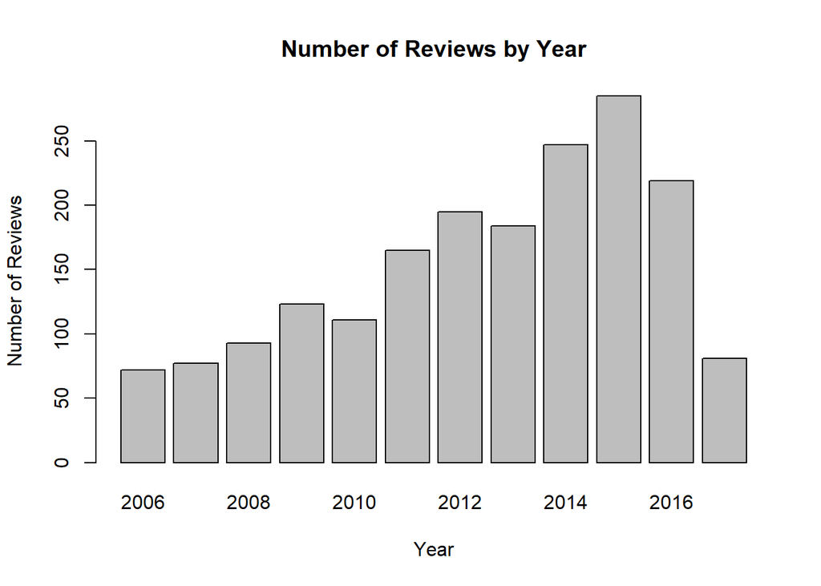

```r
year <- table(choco$Review.Date)
barplot(year, main = "Number of Reviews by Year", ylab = "Number of Reviews", xlab = "Year")
```

### 3.

```r
print(sort(table(choco$Company.Location)))
```

```
##
##    Czech Republic           Eucador             Ghana        Martinique
##                 1                 1                 1                 1
##         Niacragua       Philippines          Suriname             Wales
##                 1                 1                 1                 1
##           Bolivia             Chile           Finland             India
##                 2                 2                 2                 2
##         St. Lucia           Grenada           Iceland          Portugal
##                 2                 3                 3                 3
##            Russia         Singapore      South Africa              Fiji
##                 3                 3                 3                 4
##           Ireland            Mexico       Netherlands       Puerto Rico
##                 4                 4                 4                 4
##          Sao Tome            U.A.E. Domincan Republic         Nicaragua
##                 4                 4                 5                 5
##       South Korea            Sweden         Amsterdam          Honduras
##                 5                 5                 6                 6
##         Lithuania            Poland         Argentina        Costa Rica
##                 6                 8                 9                 9
##            Israel         Guatemala          Scotland           Vietnam
##                 9                10                10                11
##           Denmark             Japan        Madagascar       New Zealand
##                16                17                17                17
##              Peru            Brazil         Venezuela          Colombia
##                17                18                20                23
##           Hungary             Spain           Austria           Germany
##                23                26                27                36
##       Switzerland           Belgium         Australia           Ecuador
##                38                40                50                55
##             Italy              U.K.            Canada            France
##                69                98               132               158
##            U.S.A.
##               787
```

The locations with the most reviews in the dataset are the U.S, France, and Canada.

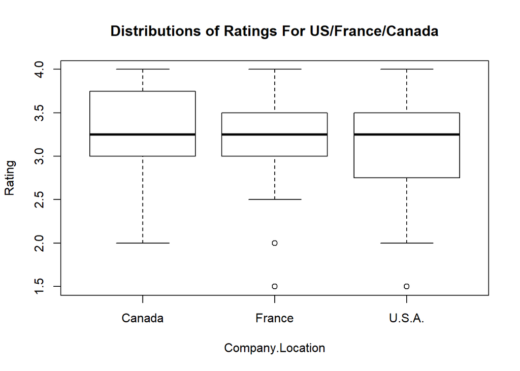

```r
chocoTopLocations <- choco[choco$Company.Location == 'U.S.A.' | choco$Company.Location == 'Canada' | choco$Company.Location == 'France', ]
chocoTopLocations <- droplevels(chocoTopLocations)
boxplot(Rating~Company.Location, data = chocoTopLocations, main = "Distributions of Ratings For US/France/Canada")
```

```r
chocoUSA <- choco[choco$Company.Location == 'U.S.A.',]
summary(chocoUSA$Rating)
```

```
##    Min. 1st Qu.  Median    Mean 3rd Qu.    Max.
##   1.500   2.750   3.250   3.162   3.500   4.000
```

```r
chocoCanada <- choco[choco$Company.Location == 'Canada',]
summary(chocoCanada$Rating)
```

```
##    Min. 1st Qu.  Median    Mean 3rd Qu.    Max.
##   2.000   3.000   3.250   3.312   3.750   4.000
```

```r
chocoFrance <- choco[choco$Company.Location == 'France',]
summary(chocoFrance$Rating)
```

```
##    Min. 1st Qu.  Median    Mean 3rd Qu.    Max.
##   1.500   3.000   3.250   3.253   3.500   4.000
```

Accross the 3 countries with the most reviews in this data set, the ratings are pretty consistent. They all have the same median with a little variance amoung their means. The spreads vary a little as well but not by much. They all have the same max rating, while Canada has a min rating .5 points higher. Their IQR’s also vary a little with USA’s being slightly lower and France’s is slightly more centered around the median.

### 4.

Does the variability in review ratings change over time?

### 5.

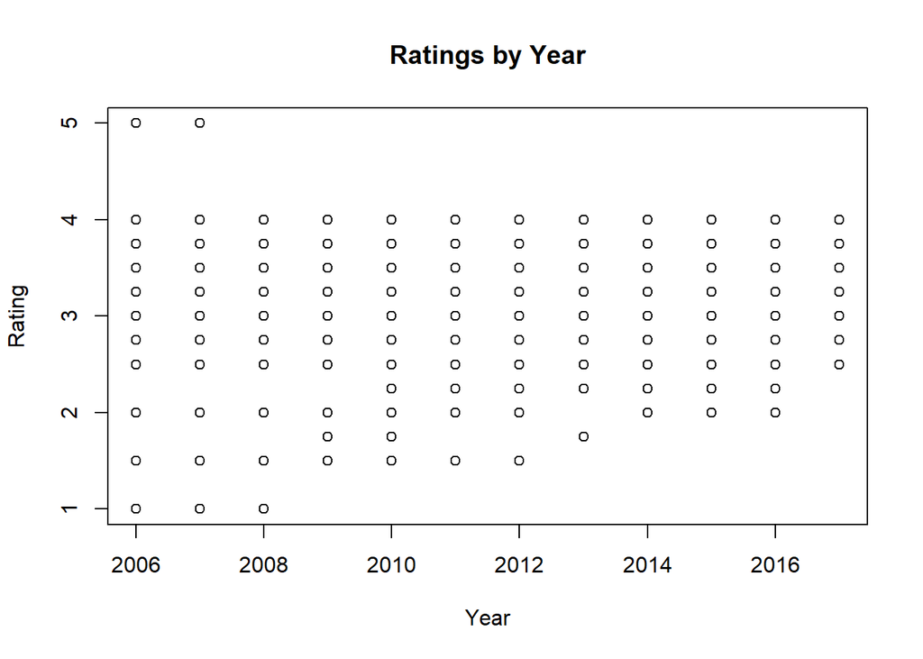

```r
plot(choco$Review.Date, choco$Rating, main = "Ratings by Year", ylab = "Rating", xlab = "Year")
```

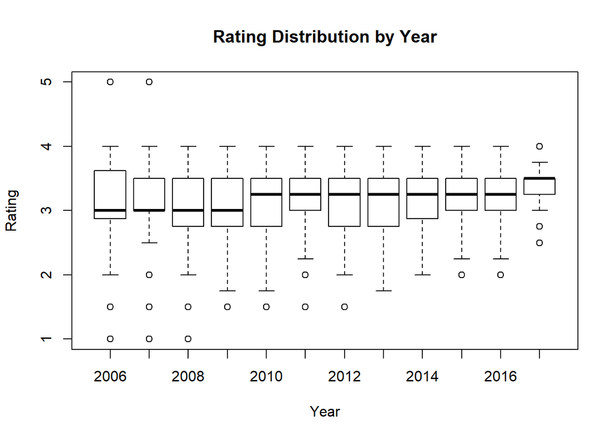

```r
boxplot(Rating~Review.Date, data = choco, main = "Rating Distribution by Year", ylab = "Rating", xlab = "Year")
```

Yes! As time has progressed, the review ratings have not been as extreme. They have more variability and a bigger spread in the early years and as time progresses the range and spread appear to get tighter.

### 6.

The process of collaborating through GitHub has been smooth and reliable for our team. Using GitHub has aided our ability to document and control the team workflow. When it came to the team portion of our lab, we worked together in person and then finished by communicating through email and pushing our work to our shared GitHub repo. The first stage was a little awkward as we were both coming up with ideas for portions of the project face to face then having to pull and push our changes to avoid having to settle any file conflicts. Not an issue though, and we didn’t have to look over each other’s shoulders as we worked together. After our in person lab time, Eli finished the next couple of problems and Jessie finished the last couple. We both then went over the other’s contributions and gave feedback. Overall it was a smooth transition from teammember to teammember and workflow was easily balanced and documented.